# Tarea Examen 1 - Aprendizaje Estadístico Automatizado

Yanely Luna Gutiérrez

3 de octubre de 2020

## REGRESIÓN LINEAL

Yanely Luna Gutiérrez

### 1. Ejercicio 9

Regresión lineal múltiple para el conjunto de datos $\texttt{auto}$.

Esta base de datos tiene información de 392 vehículos sobre 9 variables:

- $\texttt{mpg}$: Millas recorridas por galón.
- $\texttt{cyliders}$: Número de cilindros.
- $\texttt{displacement}$: Volumen útil de todos los cilindros en pulgadas cúbicas.
- $\texttt{horsepower}$: Potencia del motor (en caballos de fuerza).
- $\texttt{weight}$: Peso del vehículo en libras.
- $\texttt{acceleration}$: Tiempo en segundos que tarda en acelerar de 0 a 60mph.
- $\texttt{year}$: Año del modelo.
- $\texttt{origin}$: Origen del vehículo (1 Americano, 2 Europeo, 3 Japonés).
- $\texttt{name}$: Nombre del vehículo.

#### a)

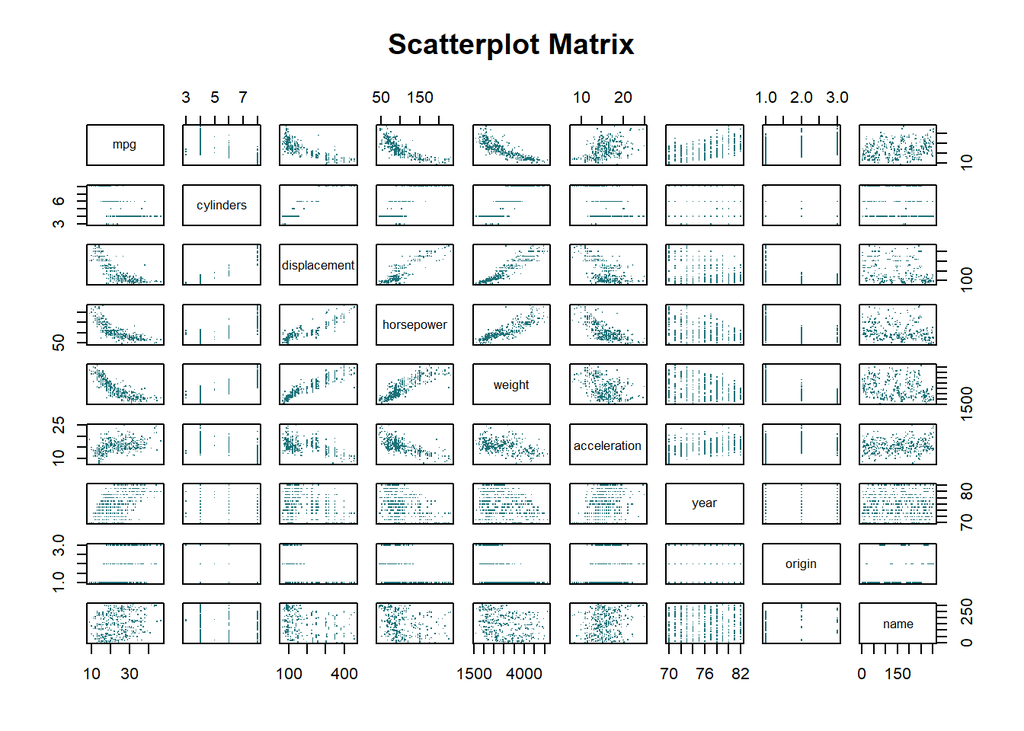

En la gráfica de dispersión por pares podemos observar la relación gráfica entre cada par de variables de la base y notamos que algunas parecen tener una relación lineal positiva (como $\texttt{displacement}$ y $\texttt{horsepower}$), mientras que en otras se observa una relación no lineal negativa (como $\texttt{mpg}$ y $\texttt{weight}$) y algunas parecen no tener una relación tan clara (en $\texttt{year}$ y $\texttt{horsepower}$). Las relaciones con la variable $\texttt{name}$ no nos dicen algo claro puesto que esta variable es solo el nombre del vehículo.

#### b) Matriz de correlaciones

|  | mpg | cylinders | displacement | horsepower | weight | acceleration | year | origin |
| --- | --- | --- | --- | --- | --- | --- | --- | --- |
| mpg | 1.0000000 | -0.7776175 | -0.8051269 | -0.7784268 | -0.8322442 | 0.4233285 | 0.5805410 | 0.5652088 |
| cylinders | -0.7776175 | 1.0000000 | 0.9508233 | 0.8429834 | 0.8975273 | -0.5046834 | -0.3456474 | -0.5689316 |
| displacement | -0.8051269 | 0.9508233 | 1.0000000 | 0.8972570 | 0.9329944 | -0.5438005 | -0.3698552 | -0.6145351 |
| horsepower | -0.7784268 | 0.8429834 | 0.8972570 | 1.0000000 | 0.8645377 | -0.6891955 | -0.4163615 | -0.4551715 |
| weight | -0.8322442 | 0.8975273 | 0.9329944 | 0.8645377 | 1.0000000 | -0.4168392 | -0.3091199 | -0.5850054 |
| acceleration | 0.4233285 | -0.5046834 | -0.5438005 | -0.6891955 | -0.4168392 | 1.0000000 | 0.2903161 | 0.2127458 |
| year | 0.5805410 | -0.3456474 | -0.3698552 | -0.4163615 | -0.3091199 | 0.2903161 | 1.0000000 | 0.1815277 |
| origin | 0.5652088 | -0.5689316 | -0.6145351 | -0.4551715 | -0.5850054 | 0.2127458 | 0.1815277 | 1.0000000 |

|  | mpg | displacement | horsepower | weight | acceleration | year |
| --- | --- | --- | --- | --- | --- | --- |
| mpg | 1.0000000 | -0.8051269 | -0.7784268 | -0.8322442 | 0.4233285 | 0.5805410 |
| displacement | -0.8051269 | 1.0000000 | 0.8972570 | 0.9329944 | -0.5438005 | -0.3698552 |
| horsepower | -0.7784268 | 0.8972570 | 1.0000000 | 0.8645377 | -0.6891955 | -0.4163615 |
| weight | -0.8322442 | 0.9329944 | 0.8645377 | 1.0000000 | -0.4168392 | -0.3091199 |
| acceleration | 0.4233285 | -0.5438005 | -0.6891955 | -0.4168392 | 1.0000000 | 0.2903161 |
| year | 0.5805410 | -0.3698552 | -0.4163615 | -0.3091199 | 0.2903161 | 1.0000000 |

En la matriz de correlaciones podemos confirmar lo que notamos en la gráfica anterior respecto a la relación lineal positiva entre $\texttt{displacement}$ y $\texttt{horsepower}$ pues su correlación es de 0.89, bastante cercana a 1.